# Lecture 19

2026-06-02

# Looking forward to Stats 102A

## Function Writing Advice from R4DS

- [Chapter 25](https://r4ds.hadley.nz/functions.html)
- Writing functions is related to exercising/strengthening your understanding of data science
- Naming: You can give your function a memorable/understandable name
- As you grow in your skills and software and methods change, you might only need to update R code in one place
- Decrease the chance mistakes
- Functions makes it easier to reuse work from past projects
- Increase your productivity over time.

## Recall

- In R, functions generally take this form: (the red is absolutely required) name and the function function

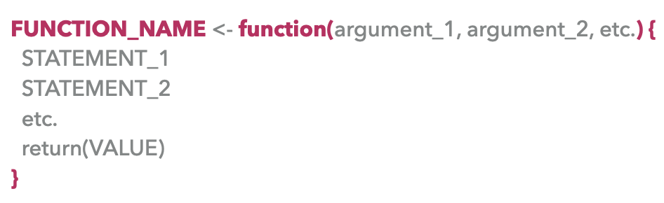

- The grey will depend on the needs of the programmer + the function
- argument_1, argument_2, etc. this known as “the formals”
- The part bracketed by { } is the body of the function
- There is a fourth part, not seen here, called the environment

## Example: sd()

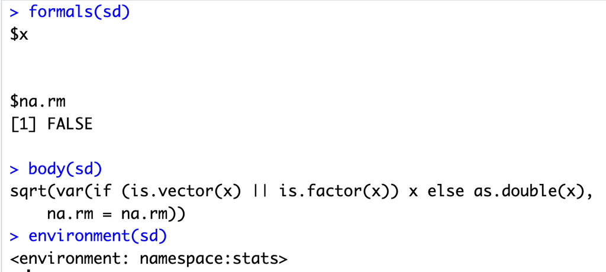

## Example: eda_summary()

- You can view your own function `View(eda_summary)`

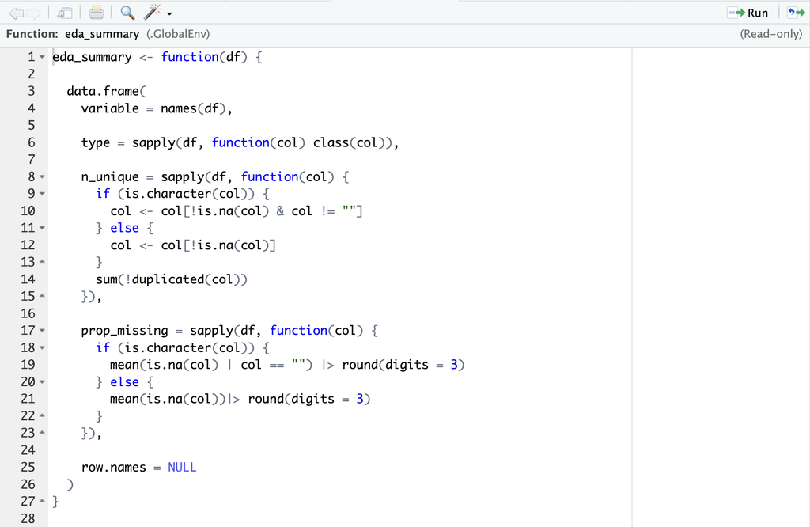

## Environments

- <environment: R_GlobalEnv>

R_GlobalEnv stands for the “Global Environment.” This is your personal work area in R.

Whenever you import a dataset, create a variable, or write your very own custom function like eda_summary(), you are storing it in your own work area. Everything here is yours. You can use, modify, or delete it. It belongs to you

- environment(sd) returned <environment: namespace:stats>

namespace:stats belongs to R.

When you installed R, it came with thousands of professional, pre-built functions. But R doesn’t dump all these functions onto your personal work area. Instead, it organizes them into other work areas (its). These areas are called “namespaces” (AKA packages). The sd() function exists in a package labeled “stats”.

## Why is this important?

- R uses environments to protect itself from us (and us from it).
- What happens if I misuse the name of `sd` for one of my own functions?

```r
sd <- function() {
  cat("I broke the standard deviation!")
}
sd()
```

```
I broke the standard deviation!
```

```r
# did I break it? kinda
real_numbers <- c(10, 20, 30)

sd(real_numbers)
```

```
Error in `sd()`:
! unused argument (real_numbers)
```

```r
# BUT
stats::sd(real_numbers)
```

```
[1] 10
```

## Recall …

- Some functions (e.g., data.frame) can accept any number of user specified-arguments.
- The … (ellipsis) argument makes this possible.
- … is employed when extending another function and the programmer does not want to copy the entire argument list of the original function.
- Be cautious when using … If an argument is misspelled it will NOT generate an error. Also any arguments used after … must be fully named.
- You can see whether an ellipsis is used in a function on the corresponding help page or with args().

```r
args(data.frame)
```

```
function (..., row.names = NULL, check.rows = FALSE, check.names = TRUE,
    fix.empty.names = TRUE, stringsAsFactors = FALSE)
NULL
```

## If I show you a function in the future…

You should be able to identify the parts:

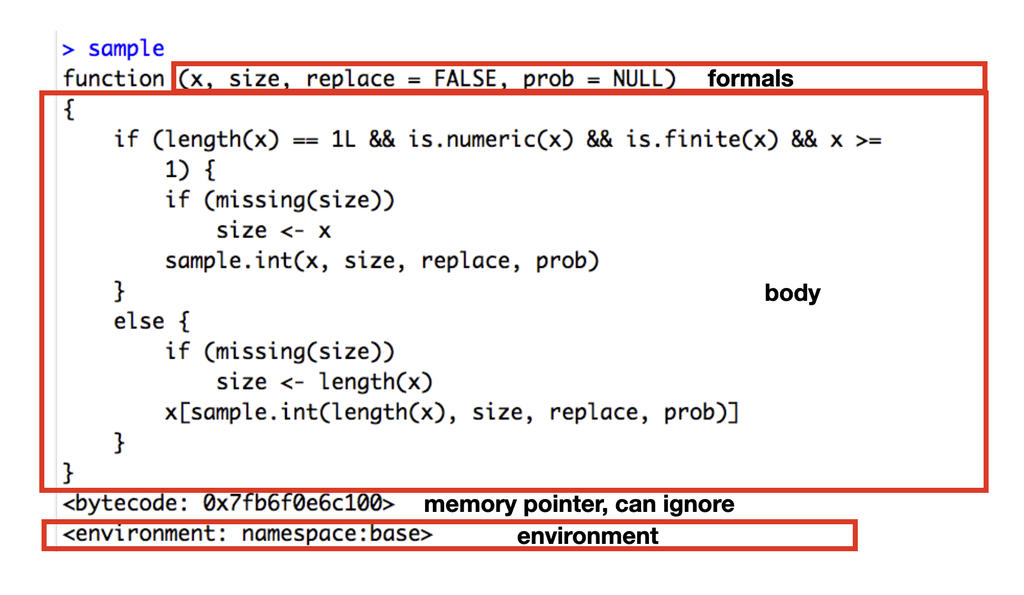

## Using return()

- If the end of a function is reached without calling return(), the value of the last evaluated expression is returned automatically by R.
- R’s behavior is different from many other languages.
- `return()` is not required, but it is *generally* considered poor style/poor communication to exclude it from a function
- But a `return()` will end your R function immediately, so either it should be the last line of a function OR it might be associated with an early termination due to error.

## Example with more than one return()

```r
my_string_n <- function(x){
  if(!is.character(x)) # understood as if character is not true
    return(print("This function requires character data!"))
  else
    return(strsplit(x, split = "") |> unlist() |> length())
}

my_string_n(155)
```

```
[1] "This function requires character data!"
```

```r
my_string_n("Therefore at such a time the prudent person keeps quiet, because it is an evil time.")
```

```
[1] 84
```

## print() vs. cat() vs. message()

- They all look the same, more or less

```r
print("🛑 Stop! In the name of love ♡")
```

```
[1] "🛑 Stop! In the name of love ♡"
```

```r
cat("🛑 Stop! In the name of love ♡", "\n") # cat needs a line break
```

```
🛑 Stop! In the name of love ♡
```

```r
message("🛑 Stop! In the name of love ♡")
```

```
🛑 Stop! In the name of love ♡
```

- Use `print()` when you are debugging code, or when you need to see a data frame, a list, or model output.
- Use `cat()` you want to format anything that the human eye can easily read on screen
- When programming functions, use `message()` because we can `suppressMessages()` when we don’t want to see them
- `cat()` and `message()` are not the same, `message()` is response to other programming related functions, `cat()` is not

## Writing Helper Functions

- Don’t be afraid to start small, like a good Stats 20 problem for your final could be “write a little helper function that converts all factors in a data frame to character” or “write a little helper function that removes all dollar signs, commas and percentage signs from your data frame”
- These helper functions can be called in other functions and re-used
- When you are programming a much more complicated function, say something for Stats 102A, try to break down the 102A problem into smaller pieces which behave like “helper functions”

## Example

- Dropping tweets that don’t really have analyzable content

```r
# helper function example
remove_RT <- function(x) {
  rt <- grepl("^RT", x$text)
  return(x[!rt,])
}
remove_WP <- function(y) {
  wp <- grepl("^http", y$text)
  return(y[!wp,])
}
remove_IMAGE <- function(z) {
  image <- grepl("^\\[", z$text)  # need \\ to escape [
  return(z[!image,])
}
```

- combine them into a single function

```r
clean_tweet <- function(x) {
  remove_RT(x) |> remove_WP() |> remove_IMAGE()
}
```

## Example (cont’d)

Always test your functions.

```r
library(readr)
sample_tweets <- suppressMessages(read_csv("data/sample_tweets.csv"))
tail(sample_tweets$text)
```

```
[1] "Kennedy Center to Be Renamed Trump-Kennedy Center: https://www. newsmax.com/us/kennedy-center- donald-trump-board/2025/12/18/id/1238860/"
[2] "Amazon to invest up to $50B to build AI infrastructure for US government agencies: https://www. foxbusiness.com/markets/amazon -invest-up-50b-build-ai-infrastructure-us-government-agencies"
[3] "[Image]"
[4] "RT: https://truthsocial.com/users/realDonaldTrump/statuses/115798247418895666"
[5] "[Video]"
[6] "RT: https://truthsocial.com/users/realDonaldTrump/statuses/115798237843100749"
```

```r
sample_tweets_cleaned <- clean_tweet(sample_tweets)
tail(sample_tweets_cleaned$text)
```

```
[1] "Trump Delivers Rousing Primetime Address, Announces “Warrior Dividend” for Troops: https:// amac.us/newsline/economy/trump -delivers-rousing-primetime-address-announces-warrior-dividend-for-troops/"
[2] "Trump Hammers the ‘Mess’ Biden Left on Border, Inflation, Wages: ‘I’m Fixing It’: https://www. breitbart.com/politics/2025/12 /18/trump-hammers-the-mess-biden-left-on-border-inflation-wages-im-fixing-it/"
[3] "Kennedy Center Board Votes Unanimously to Add Donald Trump’s Name to Iconic D.C. Venue: https://www. breitbart.com/entertainment/20 25/12/18/kennedy-center-board-votes-unanimously-to-add-donald-trumps-name-to-iconic-d-c-venue/"
[4] "Board votes Kennedy Center to be renamed 'Trump-Kennedy Center': https://www. foxnews.com/politics/board-vot es-kennedy-center-renamed-trump-kennedy-center-leavitt-says"
[5] "Kennedy Center to Be Renamed Trump-Kennedy Center: https://www. newsmax.com/us/kennedy-center- donald-trump-board/2025/12/18/id/1238860/"
[6] "Amazon to invest up to $50B to build AI infrastructure for US government agencies: https://www. foxbusiness.com/markets/amazon -invest-up-50b-build-ai-infrastructure-us-government-agencies"
```

## Local vs Global Scope

- If you examine your environment tab (your global environment) more closely, you will notice that the functions remove_RT, remove_WP, remove_IMAGE didn’t create any objects named x, y, rt, etc. behind.
- The objects used in those functions are only available within those functions and are said to have “local scope”
- The momemnt you run your own function, R instantly builds a temporary environment and performs its work in there.
- In this temporary enviroment, the function can create temporary variables, rename columns, filter rows, and do all sorts of things. This is the Local Scope.
- When the function finishes it returns a result, and temporary environment with all the other variables in it, disappears.
- Because of this, nothing done inside the function can accidentally destroy objects in the Global Environment.

## Try this during break

```r
# Make an important object in the Global Env
my_important_number <- 100

# Build a function
godzilla_function <- function() {

  # Inside the local scope, overwrite the number
  my_important_number <- 0

  # Make a new variable that only exists in function
  my_secret_variable <- "I don't think I exist"

  return("The function has finished running.")
}

# Run the function
godzilla_function()
```

```
[1] "The function has finished running."
```

```r
# Did the function destroy our object? NO
print(my_important_number)
```

```
[1] 100
```

```r
# Can we see the secret variable? NO
print(my_secret_variable)
```

```
Error:
! object 'my_secret_variable' not found
```

# Break

## More expectations from 102A

- Construct vectors, especially sequences
- Coercion, when and how to coerce, just by looking, what will the result be?

```
c(0, TRUE)
c("f", 1)
c(list(1), "b") # everything becomes a list
c(FALSE, 1L) # 1L literal integer, sometimes you see this in older code
```

- Know the difference between NULL, NA, and NaN

## NULL, NA, NaN

- Uses of NA:
  - Data is missing but should exist
  - You need to keep consistent vector length
- Uses of NaN:
  - NaN usually is a result of calculations
  - We usually don’t create it manually (maybe for a teaching example…)
- Uses of NULL:
  - Remove elements of a vector, data.frame, list
  - Have an empty list component (perhaps to fill later or grow conditionally)

## Example NaN and NULL

NaN is the result of calculation

```r
c(0/0, Inf/Inf, Inf - Inf, log(-1), sqrt(-1), asin(-2) )
```

```
[1] NaN NaN NaN NaN NaN NaN
```

NULL - used with lists and data frames

```r
iris$Species <- NULL # deleted the Species column
head(iris)
```

```
  Sepal.Length Sepal.Width Petal.Length Petal.Width
1          5.1         3.5          1.4         0.2
2          4.9         3.0          1.4         0.2
3          4.7         3.2          1.3         0.2
4          4.6         3.1          1.5         0.2
5          5.0         3.6          1.4         0.2
6          5.4         3.9          1.7         0.4
```

```r
my_list <- list(iris, NULL, c("UCLA", "fight", "fight", "fight"))
str(my_list) # created an empty list component
```

```
List of 3
 $ :'data.frame':   150 obs. of  4 variables:
  ..$ Sepal.Length: num [1:150] 5.1 4.9 4.7 4.6 5 5.4 4.6 5 4.4 4.9 ...
  ..$ Sepal.Width : num [1:150] 3.5 3 3.2 3.1 3.6 3.9 3.4 3.4 2.9 3.1 ...
  ..$ Petal.Length: num [1:150] 1.4 1.4 1.3 1.5 1.4 1.7 1.4 1.5 1.4 1.5 ...
  ..$ Petal.Width : num [1:150] 0.2 0.2 0.2 0.2 0.2 0.4 0.3 0.2 0.2 0.1 ...
 $ : NULL
 $ : chr [1:4] "UCLA" "fight" "fight" "fight"
```

You can change it later

```r
my_list[[2]] <- 1:10
str(my_list)
```

```
List of 3
 $ :'data.frame':   150 obs. of  4 variables:
  ..$ Sepal.Length: num [1:150] 5.1 4.9 4.7 4.6 5 5.4 4.6 5 4.4 4.9 ...
  ..$ Sepal.Width : num [1:150] 3.5 3 3.2 3.1 3.6 3.9 3.4 3.4 2.9 3.1 ...
  ..$ Petal.Length: num [1:150] 1.4 1.4 1.3 1.5 1.4 1.7 1.4 1.5 1.4 1.5 ...
  ..$ Petal.Width : num [1:150] 0.2 0.2 0.2 0.2 0.2 0.4 0.3 0.2 0.2 0.1 ...
 $ : int [1:10] 1 2 3 4 5 6 7 8 9 10
 $ : chr [1:4] "UCLA" "fight" "fight" "fight"
```

## Classic 102A homework problem

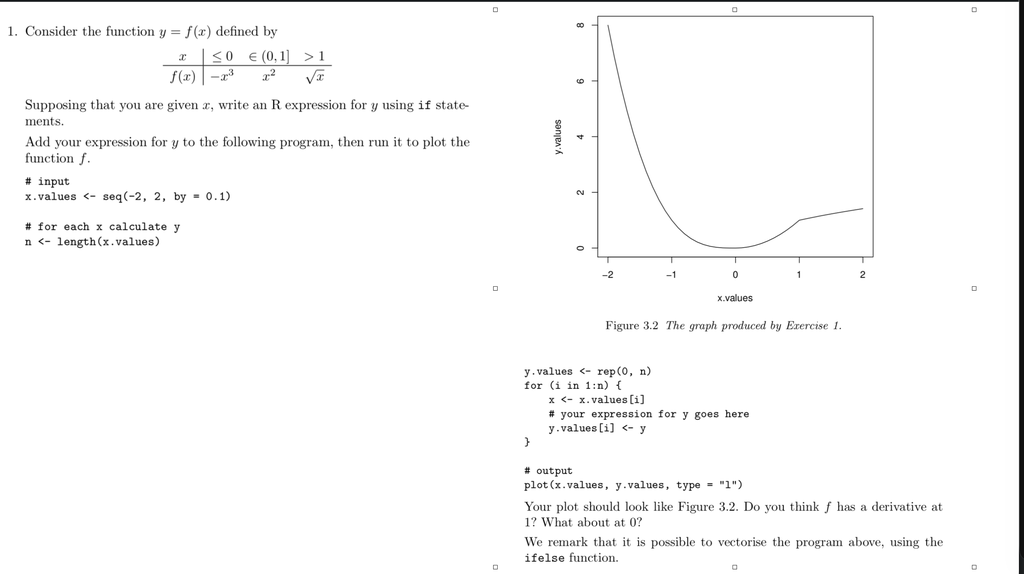

## Solution, Base R

```r
f <- function(x){
  if (x <= 0) {
    return(-x^3)
  } else if (x <= 1) {
    return(x^2)
  } else {
    return(sqrt(x))
  }
}

x_values <- seq(-2, 2, by = 0.1)

y_values <- rep(NA, length(x_values))
for (i in seq_along(x_values)) {
  x <- x_values[i]
  y_values[i] <- f(x)
}
```

## Graph

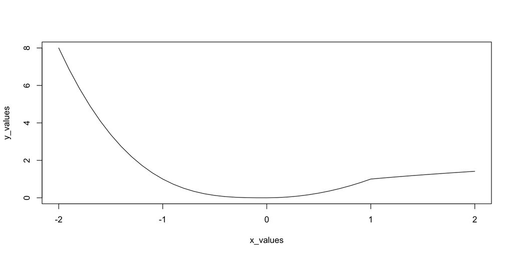

```r
plot(x_values, y_values, type = "l")
```

## A little more on environments

https://blog.thatbuthow.com/how-r-searches-and-finds-stuff/

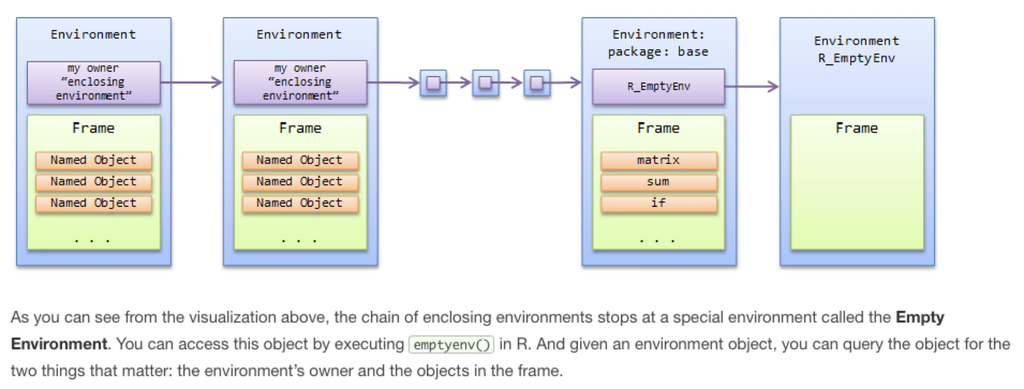

- How R manages to keep everything straight (R is well managed)

## Just a bit more

- Generally, an environment is similar to a list, with important exceptions:
- Every object in a given environment has a unique name.
- The objects in an environment are not ordered (e.g., lists components can be accessed in numerical order)
- An environment has a parent. The parent of the global environment is the last package that you attached with library() or a require().

## Relationship: package, library, environment

Suppose you issue `library(ggplot2)`, R does three things:

1. Reads your Library (a folder on your hard drive).
2. Finds ggplot2, a package that was downloaded and saved to the folder
3. It unpacks the functions, data, etc. in ggplot2 and put them into a new environment (the namespace) that you can use

```r
library(ggplot2)
scale_x_reverse
```

```
function (...)
{
    scale_x_continuous(..., transform = transform_reverse())
}
<bytecode: 0x11837c5c8>
<environment: namespace:ggplot2>
```

## When you see…

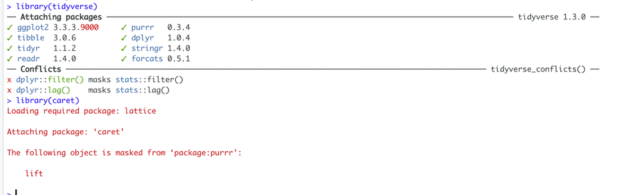

either use `::` to specify the exact package::function or reorder the `library()` calls and issue it last (just before the global environment)

## Programming with Style

- Having good style can be taught and learned, but like anything else, it takes time
- There is mostly agreement on R style, but some areas are open
- Having good style reduces errors
- Having good style reduces time spent fixing programs
- Fixing a programming problem requires more time than writing it correctly from the start

# Last Part, Some Linear Algebra

## This is not on your final, you are not asked about this material

- This relates to Chapter 6 of Braun & Murdoch
- And training in Math 33A and 115A (upper division proof based linear algebra)
- This is the mathematics of data science (and more)
- Just want to show you a few basic concepts to help inform you going forward
- And how R is used as a tool to help you see the value.

## Constructing Matrices

- matrix(), cbind() and rbind() are commonly seen

```r
matrix(c(1, 1/2, 1/3, 1/2, 1/3, 1/4, 1/3, 1/4, 1/5), nrow=3) # implies ncol = 3
```

```
          [,1]      [,2]      [,3]
[1,] 1.0000000 0.5000000 0.3333333
[2,] 0.5000000 0.3333333 0.2500000
[3,] 0.3333333 0.2500000 0.2000000
```

- also some combination of math and R functions

```r
1/cbind(seq(1, 3), seq(2, 4), seq(3, 5))
```

```
          [,1]      [,2]      [,3]
[1,] 1.0000000 0.5000000 0.3333333
[2,] 0.5000000 0.3333333 0.2500000
[3,] 0.3333333 0.2500000 0.2000000
```

- `rbind()` and `cbind()` are not really different

```r
1/rbind(seq(1, 3), seq(2, 4), seq(3, 5))
```

```
          [,1]      [,2]      [,3]
[1,] 1.0000000 0.5000000 0.3333333
[2,] 0.5000000 0.3333333 0.2500000
[3,] 0.3333333 0.2500000 0.2000000
```

## Row and Column Naming

Sometimes you might want to name your rows and columns.

```r
height <- c(172, 168, 167, 175, 180)
weight <- c(62, 64, 51, 71, 69)

matrix_5 <- cbind(height, weight) # produces a matrix
matrix_5
```

```
     height weight
[1,]    172     62
[2,]    168     64
[3,]    167     51
[4,]    175     71
[5,]    180     69
```

```r
row.names(matrix_5) <- c("Anna","Bella","Carina","Dora","Estella")

matrix_5
```

```
        height weight
Anna       172     62
Bella      168     64
Carina     167     51
Dora       175     71
Estella    180     69
```

```r
is(matrix_5)  # this could have been converted to data.frame
```

```
[1] "matrix"    "array"     "structure" "vector"
```

## Helpful base R functions for matrices

- transpose

```r
t(matrix_5)
```

```
       Anna Bella Carina Dora Estella
height  172   168    167  175     180
weight   62    64     51   71      69
```

- diagonal matrix

```r
diag(5)
```

```
     [,1] [,2] [,3] [,4] [,5]
[1,]    1    0    0    0    0
[2,]    0    1    0    0    0
[3,]    0    0    1    0    0
[4,]    0    0    0    1    0
[5,]    0    0    0    0    1
```

- diagonal with your own values

```r
diag(c(8,6,7,5), nrow = 4) # implies ncol = 4
```

```
     [,1] [,2] [,3] [,4]
[1,]    8    0    0    0
[2,]    0    6    0    0
[3,]    0    0    7    0
[4,]    0    0    0    5
```

## No desire to overwhelm

- For a guide to basics see https://stats.oarc.ucla.edu/r/seminars/r-matrix-operations/
- But I want to show you something more complex, B & M introduce the Hankel Matrix in Chapter 6 and this is a good place to end Stats 20

```r
# we initialize a matrix to be filled
H <- matrix(0, nrow = 10, ncol = 10) # NA would work too
dim(H)
```

```
[1] 10 10
```

```r
H
```

```
      [,1] [,2] [,3] [,4] [,5] [,6] [,7] [,8] [,9] [,10]
 [1,]    0    0    0    0    0    0    0    0    0     0
 [2,]    0    0    0    0    0    0    0    0    0     0
 [3,]    0    0    0    0    0    0    0    0    0     0
 [4,]    0    0    0    0    0    0    0    0    0     0
 [5,]    0    0    0    0    0    0    0    0    0     0
 [6,]    0    0    0    0    0    0    0    0    0     0
 [7,]    0    0    0    0    0    0    0    0    0     0
 [8,]    0    0    0    0    0    0    0    0    0     0
 [9,]    0    0    0    0    0    0    0    0    0     0
[10,]    0    0    0    0    0    0    0    0    0     0
```

## Convert it to a Hankel Matrix

- A Hankel Matrix is a matrix in which each ascending skew-diagonal (anti-diagonal) from left to right is constant (recall diag() above refers to the main diagonal on a matrix.)

```r
x <- 1:19 # a 10x10 Hankel Matrix needs 10 + 10 - 1 values, so 19

for (i in seq_len(nrow(H))) {
  for (j in seq_len(ncol(H))) {
      H[i, j] <- x[i + j - 1]
  }
}
H
```

```
      [,1] [,2] [,3] [,4] [,5] [,6] [,7] [,8] [,9] [,10]
 [1,]    1    2    3    4    5    6    7    8    9    10
 [2,]    2    3    4    5    6    7    8    9   10    11
 [3,]    3    4    5    6    7    8    9   10   11    12
 [4,]    4    5    6    7    8    9   10   11   12    13
 [5,]    5    6    7    8    9   10   11   12   13    14
 [6,]    6    7    8    9   10   11   12   13   14    15
 [7,]    7    8    9   10   11   12   13   14   15    16
 [8,]    8    9   10   11   12   13   14   15   16    17
 [9,]    9   10   11   12   13   14   15   16   17    18
[10,]   10   11   12   13   14   15   16   17   18    19
```

Hopefully you could see where writing your own function (it exists in a library called “matrixcalc”) is more flexible because every time I want a different size, I’ve got to change several values – this introduces potential error.

## Application of Linear Algebra

- This is way beyond the scope of Stats 20, think a year from now, maybe two years from now, maybe never. It depends on your personal choices and direction.
- When we look at sequential data — whether it is the stock market, victories on the football field, or crime patterns- it is often messy and difficulty to understand. The line on the graph may go up and down, but is there a real, underlying structure driving those movements, or is it just random chance?
- Before we try to build complex models to answer our questions, we need to know if there is anything in the data *worth* modeling.
- We will reshape a 1D timeline into a 2D memory structure: **Hankel Matrix** it isn’t just a grid of numbers — it has hidden structure.
- Braun & Murdoch leave you with “program a Hankel Matrix” - but let’s apply it to give you a taste of where this may continue for you.

## The real question re: data

- Can we describe data - in this example a matrix of many values - using fewer numbers? That’s the heart of the discipline, summarizing or in other contexts - compressing/decomposing/reducing data - into fewer values.
- In the example which follows, once the data is in the form of a **Hankel Matrix**, we employ **Singular Value Decomposition (SVD)** (I’ll briefly introduce you) a tool that can identify structure in the data
- If the data is purely random, the matrix will tell us.
- If there is a hidden cycle or patterning, the matrix will separate it from the noise.

## Some Random Data

```r
# Generate a random walk
set.seed(123)
time_steps <- 1:150
random_walk <- cumsum(rnorm(150, mean = 0, sd = 1))
head(random_walk)
```

```
[1] -0.5604756 -0.7906531  0.7680552  0.8385636  0.9678513  2.6829163
```

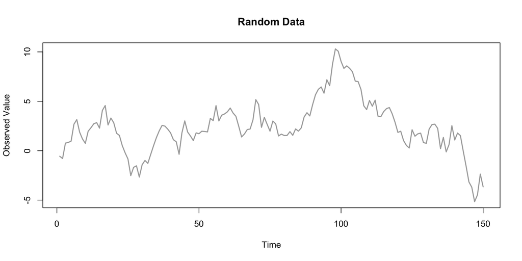

```r
# Visualize it
plot(time_steps, random_walk, type = "l", col = "darkgray", lwd = 2,
     main = "Random Data",
     ylab = "Observed Value", xlab = "Time")
```

## Construct the Hankel Matrix

```r
# Define the window size (rows) and the number of columns
L <- 30  ## the limit of L would be length(data)/2, choosing L=30 would be informed by domain knowledge
K <- length(random_walk) - L + 1

# Initialize and fill the Hankel Matrix
H_random <- matrix(0, nrow = L, ncol = K)

for (i in 1:L) {
  H_random[i, ] <- random_walk[i:(i + K - 1)]
}

dim(H_random)
```

```
[1]  30 121
```

```r
H_random[1:7, 1:7] ## examine it
```

```
           [,1]       [,2]      [,3]      [,4]      [,5]      [,6]      [,7]
[1,] -0.5604756 -0.7906531 0.7680552 0.8385636 0.9678513 2.6829163 3.1438325
[2,] -0.7906531  0.7680552 0.8385636 0.9678513 2.6829163 3.1438325 1.8787713
[3,]  0.7680552  0.8385636 0.9678513 2.6829163 3.1438325 1.8787713 1.1919184
[4,]  0.8385636  0.9678513 2.6829163 3.1438325 1.8787713 1.1919184 0.7462564
[5,]  0.9678513  2.6829163 3.1438325 1.8787713 1.1919184 0.7462564 1.9703382
[6,]  2.6829163  3.1438325 1.8787713 1.1919184 0.7462564 1.9703382 2.3301521
[7,]  3.1438325  1.8787713 1.1919184 0.7462564 1.9703382 2.3301521 2.7309235
```

## Decompose the Hankel Matrix

- Use Singular Value Decomposition (`svd()`) (Please don’t worry about the underlying calculus - continuing to study math is a personal decision). This is ultra-simplified, but bear with me
- SVD breaks the original data matrix into components: $U$ × $\Sigma$ × $V^T$
- $U$ is a matrix containing the patterns found in the data
- The values in $\Sigma$ (a diagonal matrix) tell you exactly how much of each pattern in $U$ is required to recreate the original data. (In R, it will be called “D” and it will be stored as a vector to save resources)
- $V^T$ (the T means “transpose”) this matrix contains information on how to combine the other two to get back to the original data.
- The short version: using math, we can reconstruct a good approximation of the original data matrix using only the top 1 or 2 patterns. $\Sigma$ (D in R) reveals it.

## Example

```r
# Deconstruct the matrix
svd_random <- svd(H_random)
str(svd_random)
```

```
List of 3
 $ d: num [1:30] 201.6 81.3 51.9 34.6 23.5 ...
 $ u: num [1:30, 1:30] -0.164 -0.169 -0.173 -0.176 -0.18 ...
 $ v: num [1:121, 1:30] -0.0326 -0.032 -0.0313 -0.03 -0.0292 ...
```

```r
is(svd_random$d)
```

```
[1] "numeric" "vector"
```

```r
is(svd_random$u)
```

```
[1] "matrix"    "array"     "structure" "vector"
```

```r
is(svd_random$v)
```

```
[1] "matrix"    "array"     "structure" "vector"
```

## Visualize

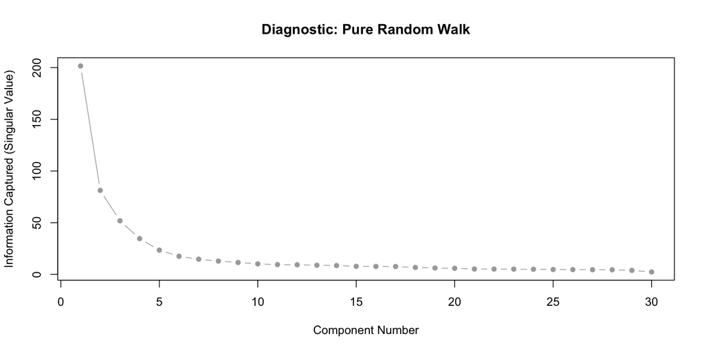

```r
# Plot the singular values (the "importance" of each component)
plot(svd_random$d, type = "b", pch = 16, col = "darkgray",
     main = "Diagnostic: Pure Random Walk",
     ylab = "Information Captured (Singular Value)",
     xlab = "Component Number")
```

## Some non-random data

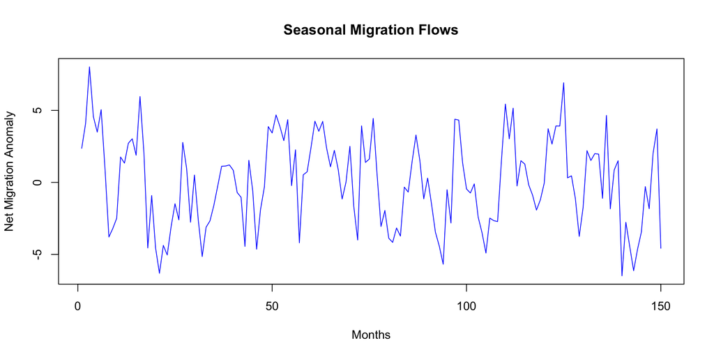

```r
# Let's say every 12 months something happens and every 60 months too
true_cycle <- 3 * sin(2 * pi * time_steps / 12) + 2 * cos(2 * pi * time_steps / 60)

# create some random noise
set.seed(123)
noise <- rnorm(150, mean = 0, sd = 2)

# combine to make our data look more real
migration_flow <- true_cycle + noise

# visualize
plot(time_steps, migration_flow, type = "l", col = "blue", lwd = 1,
     main = "Seasonal Migration Flows",
     ylab = "Net Migration Anomaly", xlab = "Months")
```

## Hankel Matrix Again

```r
L <- 30
K <- length(migration_flow) - L + 1

# Build the Hankel Matrix for the migration data
H_flow <- matrix(0, nrow = L, ncol = K)
for (i in 1:L) {
  H_flow[i, ] <- migration_flow[i:(i + K - 1)]
}

H_flow[1:5, 1:5]
```

```
         [,1]     [,2]      [,3]       [,4]       [,5]
[1,] 2.368092 4.094016 8.0195297  4.5661839  3.4906263
[2,] 4.094016 8.019530 4.5661839  3.4906263  5.0481640
[3,] 8.019530 4.566184 3.4906263  5.0481640  0.9081221
[4,] 4.566184 3.490626 5.0481640  0.9081221 -3.7899375
[5,] 3.490626 5.048164 0.9081221 -3.7899375 -3.1981352
```

## Deconstruct with SVD

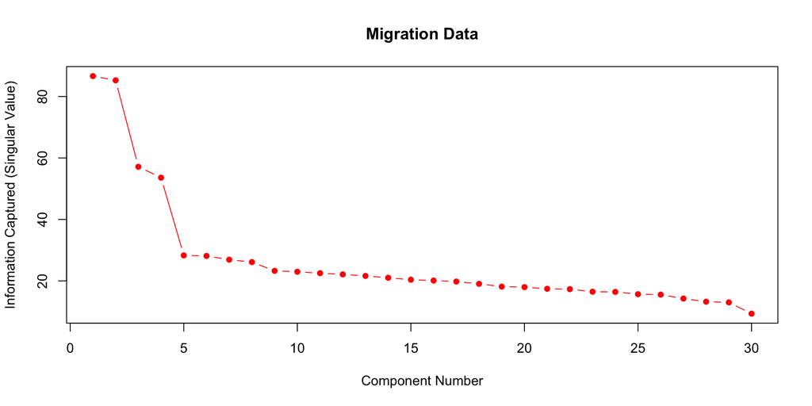

```r
svd_flow <- svd(H_flow)

plot(svd_flow$d, type = "b", pch = 16, col = "red",
     main = "Migration Data",
     ylab = "Information Captured (Singular Value)",
     xlab = "Component Number")
```

## Reconstruct it?

Sure. And we can check to see it is the same.

```r
reconstructed_cycle <- svd_flow$u %*% diag(svd_flow$d) %*% t(svd_flow$v)
all.equal(reconstructed_cycle[1:5, 1:5], H_flow[1:5, 1:5])
```

```
[1] TRUE
```

- We started Stats 20 by saying it is just a fancy calculator (maybe a fancy graphing calculator)
- And it really is just that.